# **Problem Statement**

#### **Business Context**

Understanding customer personality and behavior is pivotal for businesses to enhance customer satisfaction and increase revenue. Segmentation based on a customer's personality, demographics, and purchasing behavior allows companies to create tailored marketing campaigns, improve customer retention, and optimize product offerings.

A leading retail company with a rapidly growing customer base seeks to gain deeper insights into their customers' profiles. The company recognizes that understanding customer personalities, lifestyles, and purchasing habits can unlock significant opportunities for personalizing marketing strategies and creating loyalty programs. These insights can help address critical business challenges, such as improving the effectiveness of marketing campaigns, identifying high-value customer groups, and fostering long-term relationships with customers.

With the competition intensifying in the retail space, moving away from generic strategies to more targeted and personalized approaches is essential for sustaining a competitive edge.

#### **Objective**

In an effort to optimize marketing efficiency and enhance customer experience, the company has embarked on a mission to identify distinct customer segments. By understanding the characteristics, preferences, and behaviors of each group, the company aims to:

1. Develop personalized marketing campaigns to increase conversion rates.
2. Create effective retention strategies for high-value customers.
3. Optimize resource allocation, such as inventory management, pricing strategies, and store layouts.

As a data scientist tasked with this project, your responsibility is to analyze the given customer data, apply machine learning techniques to segment the customer base, and provide actionable insights into the characteristics of each segment.

#### **Data Dictionary**

The dataset includes historical data on customer demographics, personality traits, and purchasing behaviors. Key attributes are:

1. **Customer Information**
   - **ID:** Unique identifier for each customer.
   - **Year_Birth:** Customer's year of birth.
   - **Education:** Education level of the customer.
   - **Marital_Status:** Marital status of the customer.
   - **Income:** Yearly household income (in dollars).
   - **Kidhome:** Number of children in the household.
   - **Teenhome:** Number of teenagers in the household.
   - **Dt_Customer:** Date when the customer enrolled with the company.
   - **Recency:** Number of days since the customer’s last purchase.
   - **Complain:** Whether the customer complained in the last 2 years (1 for yes, 0 for no).
2. **Spending Information (Last 2 Years)**
   - **MntWines:** Amount spent on wine.
   - **MntFruits:** Amount spent on fruits.
   - **MntMeatProducts:** Amount spent on meat.
   - **MntFishProducts:** Amount spent on fish.
   - **MntSweetProducts:** Amount spent on sweets.
   - **MntGoldProds:** Amount spent on gold products.
3. **Purchase and Campaign Interaction**
   - **NumDealsPurchases:** Number of purchases made using a discount.
   - **AcceptedCmp1:** Response to the 1st campaign (1 for yes, 0 for no).
   - **AcceptedCmp2:** Response to the 2nd campaign (1 for yes, 0 for no).
   - **AcceptedCmp3:** Response to the 3rd campaign (1 for yes, 0 for no).
   - **AcceptedCmp4:** Response to the 4th campaign (1 for yes, 0 for no).
   - **AcceptedCmp5:** Response to the 5th campaign (1 for yes, 0 for no).
   - **Response:** Response to the last campaign (1 for yes, 0 for no).
4. **Shopping Behavior**
   - **NumWebPurchases:** Number of purchases made through the company’s website.
   - **NumCatalogPurchases:** Number of purchases made using catalogs.
   - **NumStorePurchases:** Number of purchases made directly in stores.
   - **NumWebVisitsMonth:** Number of visits to the company’s website in the last month.

# **Let's start coding!**

## **Importing necessary libraries**

```python
# Libraries to help with reading and manipulating data
import pandas as pd
import numpy as np

# libaries to help with data visualization
import matplotlib.pyplot as plt
import seaborn as sns

# Removes the limit for the number of displayed columns
pd.set_option("display.max_columns", None)
# Sets the limit for the number of displayed rows
pd.set_option("display.max_rows", 200)

# to scale the data using z-score
from sklearn.preprocessing import StandardScaler

# to compute distances
from scipy.spatial.distance import cdist, pdist

# to perform k-means clustering and compute silhouette scores
from sklearn.cluster import KMeans
from sklearn.metrics import silhouette_score

# to visualize the elbow curve and silhouette scores
from yellowbrick.cluster import KElbowVisualizer, SilhouetteVisualizer

# to suppress warnings
import warnings

import time

warnings.filterwarnings("ignore")
```

## **Loading the data**

```python
from google.colab import drive
drive.mount('/content/drive')
```

```python
# loading data into a pandas dataframe
df = pd.read_csv("/content/drive/MyDrive/Customer_Personality_Segmentation.csv", sep="\t")
```

```python
from google.colab import drive
drive.mount('/content/drive')
```

## **Data Overview**

```python
df.head()
```

|  | ID | Year_Birth | Education | Marital_Status | Income | Kidhome | Teenhome | Dt_Customer | Recency | MntWines | MntFruits | MntMeatProducts | MntFishProducts | MntSweetProducts | MntGoldProds | NumDealsPurchases | NumWebPurchases | NumCatalogPurchases | NumStorePurchases | NumWebVisitsMonth | AcceptedCmp3 | AcceptedCmp4 | AcceptedCmp5 | AcceptedCmp1 | AcceptedCmp2 | Complain | Z_CostContact | Z_Revenue | Response |
| --- | --- | --- | --- | --- | --- | --- | --- | --- | --- | --- | --- | --- | --- | --- | --- | --- | --- | --- | --- | --- | --- | --- | --- | --- | --- | --- | --- | --- | --- |
| 0 | 5524 | 1957 | Graduation | Single | 58138.0 | 0 | 0 | 04-09-2012 | 58 | 635 | 88 | 546 | 172 | 88 | 88 | 3 | 8 | 10 | 4 | 7 | 0 | 0 | 0 | 0 | 0 | 0 | 3 | 11 | 1 |
| 1 | 2174 | 1954 | Graduation | Single | 46344.0 | 1 | 1 | 08-03-2014 | 38 | 11 | 1 | 6 | 2 | 1 | 6 | 2 | 1 | 1 | 2 | 5 | 0 | 0 | 0 | 0 | 0 | 0 | 3 | 11 | 0 |
| 2 | 4141 | 1965 | Graduation | Together | 71613.0 | 0 | 0 | 21-08-2013 | 26 | 426 | 49 | 127 | 111 | 21 | 42 | 1 | 8 | 2 | 10 | 4 | 0 | 0 | 0 | 0 | 0 | 0 | 3 | 11 | 0 |
| 3 | 6182 | 1984 | Graduation | Together | 26646.0 | 1 | 0 | 10-02-2014 | 26 | 11 | 4 | 20 | 10 | 3 | 5 | 2 | 2 | 0 | 4 | 6 | 0 | 0 | 0 | 0 | 0 | 0 | 3 | 11 | 0 |
| 4 | 5324 | 1981 | PhD | Married | 58293.0 | 1 | 0 | 19-01-2014 | 94 | 173 | 43 | 118 | 46 | 27 | 15 | 5 | 5 | 3 | 6 | 5 | 0 | 0 | 0 | 0 | 0 | 0 | 3 | 11 | 0 |

#### **Question 1**: What are the data types of all the columns?

```python
df.info()
```

```
<class 'pandas.core.frame.DataFrame'>
RangeIndex: 2240 entries, 0 to 2239
Data columns (total 29 columns):
 #   Column               Non-Null Count  Dtype
---  ------               --------------  -----
 0   ID                   2240 non-null   int64
 1   Year_Birth           2240 non-null   int64
 2   Education            2240 non-null   object
 3   Marital_Status       2240 non-null   object
 4   Income               2216 non-null   float64
 5   Kidhome              2240 non-null   int64
 6   Teenhome             2240 non-null   int64
 7   Dt_Customer          2240 non-null   object
 8   Recency              2240 non-null   int64
 9   MntWines             2240 non-null   int64
```

[output cut: 21 more lines]

##### **Observations:**

Most of the values are integer, except of `Income` which is a float, and also some categorical values:

- Education
- Marital status
- Dt_customer

`Dt_customer` has object type instead of datetime.

There are some columns that does not make sense for this analysis. For example: `ID` column does not apport anything valuable. So, i will remove this column. Same for `AcceptedCmp*` ,`Education`, `Marital status` and `Dt_customer` variables.

```python
original_df = df.copy(deep=True)

remove_columns = ['ID', 'AcceptedCmp1', 'AcceptedCmp2', 'AcceptedCmp3', 'AcceptedCmp4', 'AcceptedCmp5', 'Education', 'Marital_Status', 'Dt_Customer']
df = df.drop(remove_columns, axis=1)
```

```python
df.head()
```

|  | Year_Birth | Income | Kidhome | Teenhome | Recency | MntWines | MntFruits | MntMeatProducts | MntFishProducts | MntSweetProducts | MntGoldProds | NumDealsPurchases | NumWebPurchases | NumCatalogPurchases | NumStorePurchases | NumWebVisitsMonth | Complain | Z_CostContact | Z_Revenue | Response |
| --- | --- | --- | --- | --- | --- | --- | --- | --- | --- | --- | --- | --- | --- | --- | --- | --- | --- | --- | --- | --- |
| 0 | 1957 | 58138.0 | 0 | 0 | 58 | 635 | 88 | 546 | 172 | 88 | 88 | 3 | 8 | 10 | 4 | 7 | 0 | 3 | 11 | 1 |
| 1 | 1954 | 46344.0 | 1 | 1 | 38 | 11 | 1 | 6 | 2 | 1 | 6 | 2 | 1 | 1 | 2 | 5 | 0 | 3 | 11 | 0 |
| 2 | 1965 | 71613.0 | 0 | 0 | 26 | 426 | 49 | 127 | 111 | 21 | 42 | 1 | 8 | 2 | 10 | 4 | 0 | 3 | 11 | 0 |
| 3 | 1984 | 26646.0 | 1 | 0 | 26 | 11 | 4 | 20 | 10 | 3 | 5 | 2 | 2 | 0 | 4 | 6 | 0 | 3 | 11 | 0 |
| 4 | 1981 | 58293.0 | 1 | 0 | 94 | 173 | 43 | 118 | 46 | 27 | 15 | 5 | 5 | 3 | 6 | 5 | 0 | 3 | 11 | 0 |

#### **Question 2:** Check the statistical summary of the data. What is the average household income?:

```python
df.describe()
```

|  | Year_Birth | Income | Kidhome | Teenhome | Recency | MntWines | MntFruits | MntMeatProducts | MntFishProducts | MntSweetProducts | MntGoldProds | NumDealsPurchases | NumWebPurchases | NumCatalogPurchases | NumStorePurchases | NumWebVisitsMonth | Complain | Z_CostContact | Z_Revenue | Response |
| --- | --- | --- | --- | --- | --- | --- | --- | --- | --- | --- | --- | --- | --- | --- | --- | --- | --- | --- | --- | --- |
| count | 2240.000000 | 2216.000000 | 2240.000000 | 2240.000000 | 2240.000000 | 2240.000000 | 2240.000000 | 2240.000000 | 2240.000000 | 2240.000000 | 2240.000000 | 2240.000000 | 2240.000000 | 2240.000000 | 2240.000000 | 2240.000000 | 2240.000000 | 2240.0 | 2240.0 | 2240.000000 |
| mean | 1968.805804 | 52247.251354 | 0.444196 | 0.506250 | 49.109375 | 303.935714 | 26.302232 | 166.950000 | 37.525446 | 27.062946 | 44.021875 | 2.325000 | 4.084821 | 2.662054 | 5.790179 | 5.316518 | 0.009375 | 3.0 | 11.0 | 0.149107 |
| std | 11.984069 | 25173.076661 | 0.538398 | 0.544538 | 28.962453 | 336.597393 | 39.773434 | 225.715373 | 54.628979 | 41.280498 | 52.167439 | 1.932238 | 2.778714 | 2.923101 | 3.250958 | 2.426645 | 0.096391 | 0.0 | 0.0 | 0.356274 |
| min | 1893.000000 | 1730.000000 | 0.000000 | 0.000000 | 0.000000 | 0.000000 | 0.000000 | 0.000000 | 0.000000 | 0.000000 | 0.000000 | 0.000000 | 0.000000 | 0.000000 | 0.000000 | 0.000000 | 0.000000 | 3.0 | 11.0 | 0.000000 |
| 25% | 1959.000000 | 35303.000000 | 0.000000 | 0.000000 | 24.000000 | 23.750000 | 1.000000 | 16.000000 | 3.000000 | 1.000000 | 9.000000 | 1.000000 | 2.000000 | 0.000000 | 3.000000 | 3.000000 | 0.000000 | 3.0 | 11.0 | 0.000000 |
| 50% | 1970.000000 | 51381.500000 | 0.000000 | 0.000000 | 49.000000 | 173.500000 | 8.000000 | 67.000000 | 12.000000 | 8.000000 | 24.000000 | 2.000000 | 4.000000 | 2.000000 | 5.000000 | 6.000000 | 0.000000 | 3.0 | 11.0 | 0.000000 |
| 75% | 1977.000000 | 68522.000000 | 1.000000 | 1.000000 | 74.000000 | 504.250000 | 33.000000 | 232.000000 | 50.000000 | 33.000000 | 56.000000 | 3.000000 | 6.000000 | 4.000000 | 8.000000 | 7.000000 | 0.000000 | 3.0 | 11.0 | 0.000000 |
| max | 1996.000000 | 666666.000000 | 2.000000 | 2.000000 | 99.000000 | 1493.000000 | 199.000000 | 1725.000000 | 259.000000 | 263.000000 | 362.000000 | 15.000000 | 27.000000 | 28.000000 | 13.000000 | 20.000000 | 1.000000 | 3.0 | 11.0 | 1.000000 |

##### **Observations:**

The average `Income` is 52247.251354.

For the variables `Z_CostContact` and `Z_Revenue`, we can see that all the statistics are the same value (3 and 11) and the standar deviation is 0 for both variables, what we can get from here, is that these variables do not add any value. We can remove these columns.

```python
df = df.drop(['Z_CostContact', 'Z_Revenue'], axis=1)
```

#### **Question 3:** Are there any missing values in the data? If yes, treat them using an appropriate method

```python
df.isnull().sum()
```

|  | 0 |
| --- | --- |
| Year_Birth | 0 |
| Income | 24 |
| Kidhome | 0 |
| Teenhome | 0 |
| Recency | 0 |
| MntWines | 0 |
| MntFruits | 0 |
| MntMeatProducts | 0 |
| MntFishProducts | 0 |
| MntSweetProducts | 0 |
| MntGoldProds | 0 |
| NumDealsPurchases | 0 |
| NumWebPurchases | 0 |
| NumCatalogPurchases | 0 |
| NumStorePurchases | 0 |
| NumWebVisitsMonth | 0 |
| Complain | 0 |
| Response | 0 |

**dtype:** int64

```python
# percentage of nulls
print("Total length", len(df))
print("Percentage of nulls:")
df.isnull().sum()/len(df)*100
```

```
Total length 2240
Percentage of nulls:
```

|  | 0 |
| --- | --- |
| Year_Birth | 0.000000 |
| Income | 1.071429 |
| Kidhome | 0.000000 |
| Teenhome | 0.000000 |
| Recency | 0.000000 |
| MntWines | 0.000000 |
| MntFruits | 0.000000 |
| MntMeatProducts | 0.000000 |
| MntFishProducts | 0.000000 |
| MntSweetProducts | 0.000000 |
| MntGoldProds | 0.000000 |
| NumDealsPurchases | 0.000000 |
| NumWebPurchases | 0.000000 |
| NumCatalogPurchases | 0.000000 |
| NumStorePurchases | 0.000000 |
| NumWebVisitsMonth | 0.000000 |
| Complain | 0.000000 |
| Response | 0.000000 |

**dtype:** float64

##### **Observations:**

We only have 24 rows with null values (~1%). One way is to impute this value or remove those files. Since this is a very low number, i prefer to remove these values.

```python
# Remove those null values.
df = df.dropna()
print("New length is: ", len(df))
```

```
New length is:  2216
```

#### **Question 4**: Are there any duplicates in the data?

```python
df.duplicated().sum()
```

```
np.int64(186)
```

##### **Observations:**

We have 186 duplicated. I will remove them and keep only the first appearance.

```python
df = df.drop_duplicates(keep='first')
```

```python
df.info()
```

```
<class 'pandas.core.frame.DataFrame'>
Index: 2030 entries, 0 to 2239
Data columns (total 18 columns):
 #   Column               Non-Null Count  Dtype
---  ------               --------------  -----
 0   Year_Birth           2030 non-null   int64
 1   Income               2030 non-null   float64
 2   Kidhome              2030 non-null   int64
 3   Teenhome             2030 non-null   int64
 4   Recency              2030 non-null   int64
 5   MntWines             2030 non-null   int64
 6   MntFruits            2030 non-null   int64
 7   MntMeatProducts      2030 non-null   int64
 8   MntFishProducts      2030 non-null   int64
 9   MntSweetProducts     2030 non-null   int64
 10  MntGoldProds         2030 non-null   int64
 11  NumDealsPurchases    2030 non-null   int64
 12  NumWebPurchases      2030 non-null   int64
 13  NumCatalogPurchases  2030 non-null   int64
 14  NumStorePurchases    2030 non-null   int64
 15  NumWebVisitsMonth    2030 non-null   int64
 16  Complain             2030 non-null   int64
 17  Response             2030 non-null   int64
dtypes: float64(1), int64(17)
memory usage: 301.3 KB
```

## **Exploratory Data Analysis**

### Univariate Analysis

#### **Question 5:** Explore all the variables and provide observations on their distributions. (histograms and boxplots)

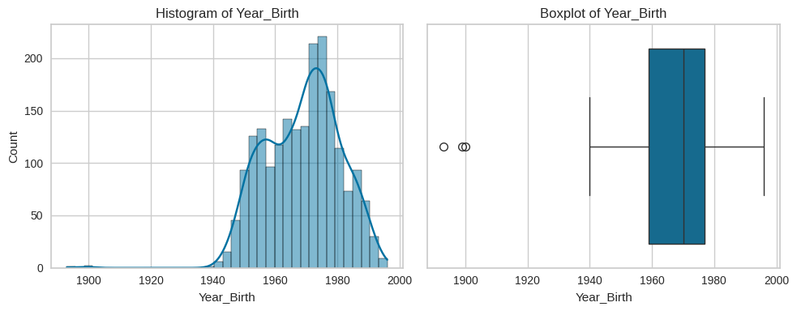

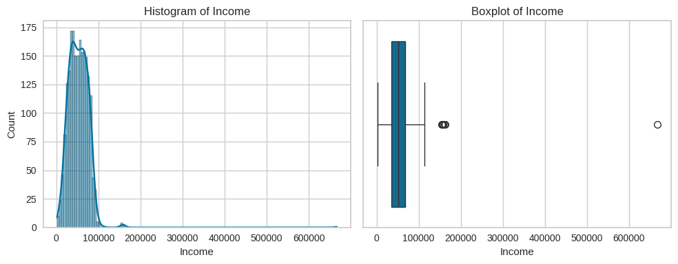

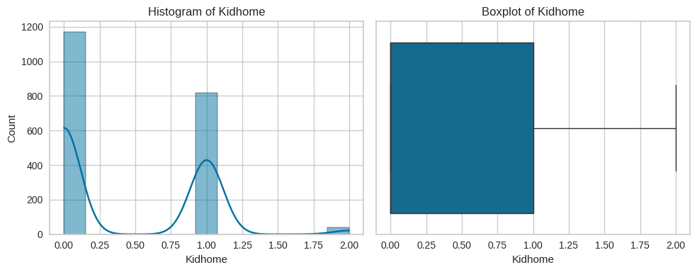

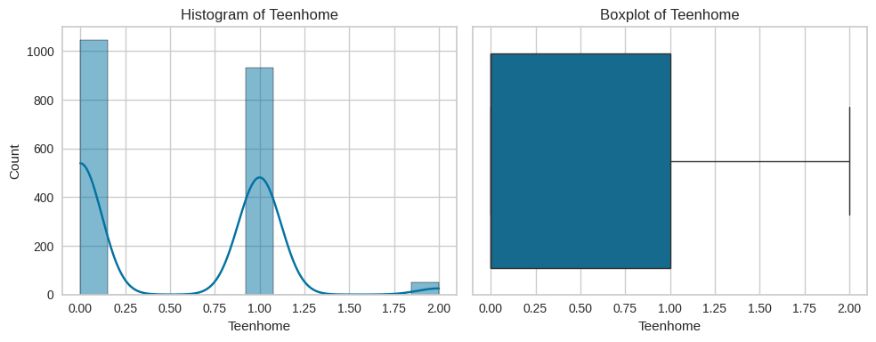

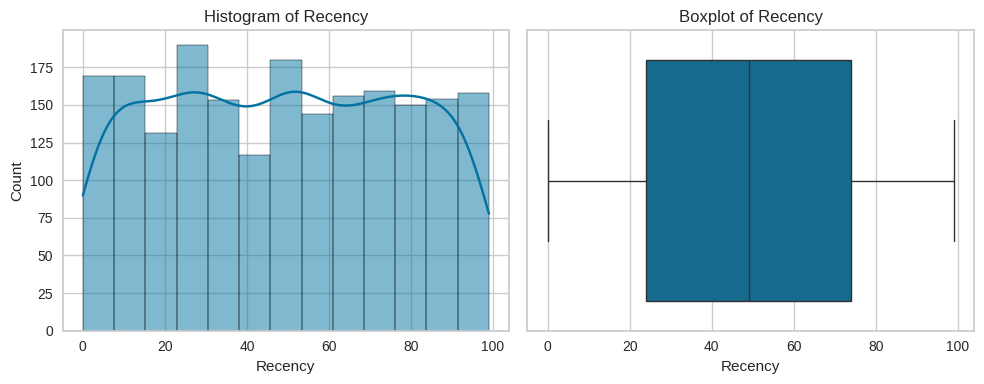

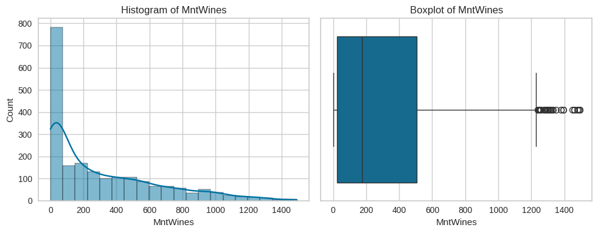

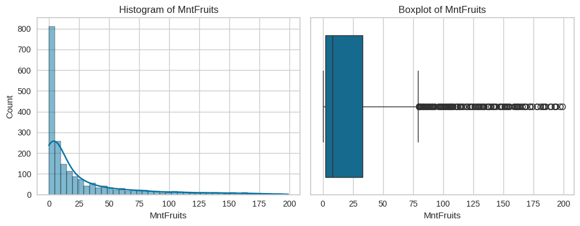

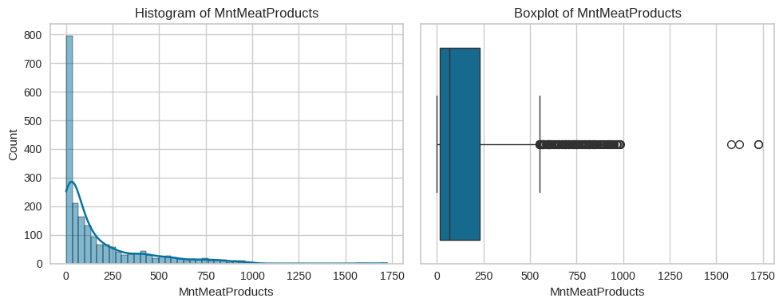

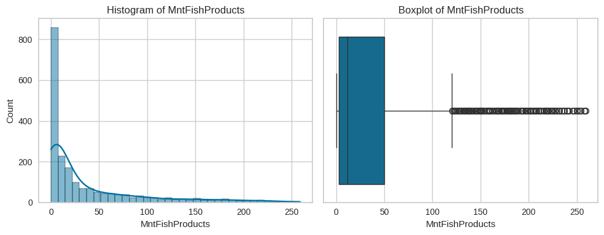

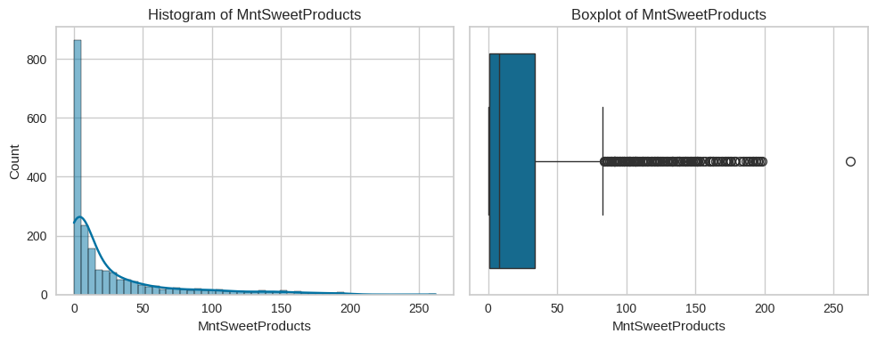

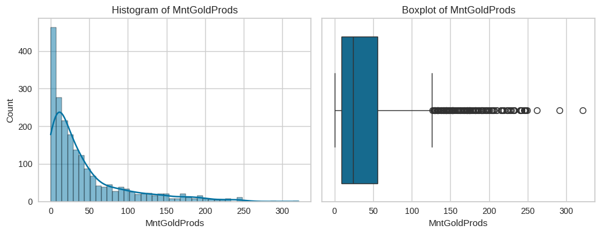

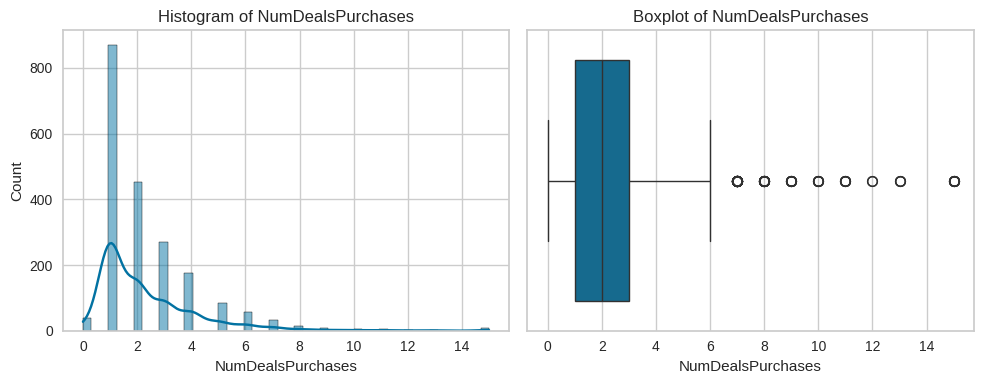

[6 more figures not shown]

```python
# Plot histograms and boxplots for each numerical column
for col in df.columns:
    plt.figure(figsize=(10, 4))

    # Histogram
    plt.subplot(1, 2, 1)
    sns.histplot(df[col], kde=True)
    plt.title(f'Histogram of {col}')

    # Boxplot
    plt.subplot(1, 2, 2)
    sns.boxplot(x=df[col])
    plt.title(f'Boxplot of {col}')

    plt.tight_layout()
    plt.show()
```

##### **Observations:**

I will make some observations of the most important ones: `year_birth`: We can see that most of the people of this dataset was born between 1960 and 1980. However there are a few outliers that are not correct. There are 3 outliers that we should remove. If we run `df[df['Year_Birth'] < 1940]` we see that these people have more than 120 years, which is not possible.

`Income`: values are concentrated between 35000 and 70000 aprox. The median is about 51381. The distribution is positive skewed. Also we can see there is a very high outlier.

`KidHome` and `TeenHome`: possible values: 0, 1 or 2. Median is 0. That means 50% of homes do not have kids or teens. Both distrinbutions are Positive skewed and they do not have any outliers.

`Recency`: Values are distributed uniformly across all the ragne. The median is at 49, this is nearly symmetrical and there are not any outliers.

We can see that most of the `Mnt*` variables are concentrated in low values, with the median and the central 50% of the data concentrate close to zero. Medians are very low compared to the maximum range of the variables. All variables show a long tail and a significant number of outliers. The distribution is positive skewed.

`NumDealsPurchases`: Most of customers make few purchases with deals, heavily concentrated between 1 and 3. The median is 2. The distribution is positively skewed. A group of significant outliers is visible starting from approximately 7 purchases and reaching up to 15.

`NumWebPurchases`: Most customers make between 2 and 6 web purchases. The median is at 4. The distribution is positively skewed. Three important and extreme outliers are visible, concentrated between 22 and 26 purchases. These values are very high compared to the rest.

`NumCatalogPurchases`: Most values are concentrated between 1 and 4. The median is at 2. The distribution is positively skewed. There are three significant outliers are observed at the high end, around 11, 22, and 27 purchases.

`NumStorePurchases` Most in-store purchases are concentrated between 3 and 8. The median is at 5. The distribution is slightly positively skewed. There are no outliers.

`NumWebVisitsMonth`: Most customers visit the website between 4 and 7 times per month. The median is at 6. The distribution is slightly positively skewed. There are four outliers observed at around 14, 17, 19, and 20 visits.

```python
# Calculate the percentage of 'Complain' where the value is 1
complain_percentage = (df['Complain'].sum() / len(df)) * 100
print(f"Percentage of 'Complain' with value 1: {complain_percentage:.2f}%")

# Remove this column
df = df.drop('Complain', axis=1)

# we need to check that there are no new duplicated values
print("New duplicated values: ", df.duplicated().sum())
```

```
Percentage of 'Complain' with value 1: 0.99%
New duplicated values:  0
```

```python
df[df['Year_Birth'] < 1940]
```

|  | Year_Birth | Income | Kidhome | Teenhome | Recency | MntWines | MntFruits | MntMeatProducts | MntFishProducts | MntSweetProducts | MntGoldProds | NumDealsPurchases | NumWebPurchases | NumCatalogPurchases | NumStorePurchases | NumWebVisitsMonth | Response |
| --- | --- | --- | --- | --- | --- | --- | --- | --- | --- | --- | --- | --- | --- | --- | --- | --- | --- |
| 192 | 1900 | 36640.0 | 1 | 0 | 99 | 15 | 6 | 8 | 7 | 4 | 25 | 1 | 2 | 1 | 2 | 5 | 0 |
| 239 | 1893 | 60182.0 | 0 | 1 | 23 | 8 | 0 | 5 | 7 | 0 | 2 | 1 | 1 | 0 | 2 | 4 | 0 |
| 339 | 1899 | 83532.0 | 0 | 0 | 36 | 755 | 144 | 562 | 104 | 64 | 224 | 1 | 4 | 6 | 4 | 1 | 0 |

```python
# remove those where year_birth < 1940
df = df[df['Year_Birth'] >= 1940]
```

### Bivariate Analysis

#### **Question 6:** Perform multivariate analysis to explore the relationsips between the variables.

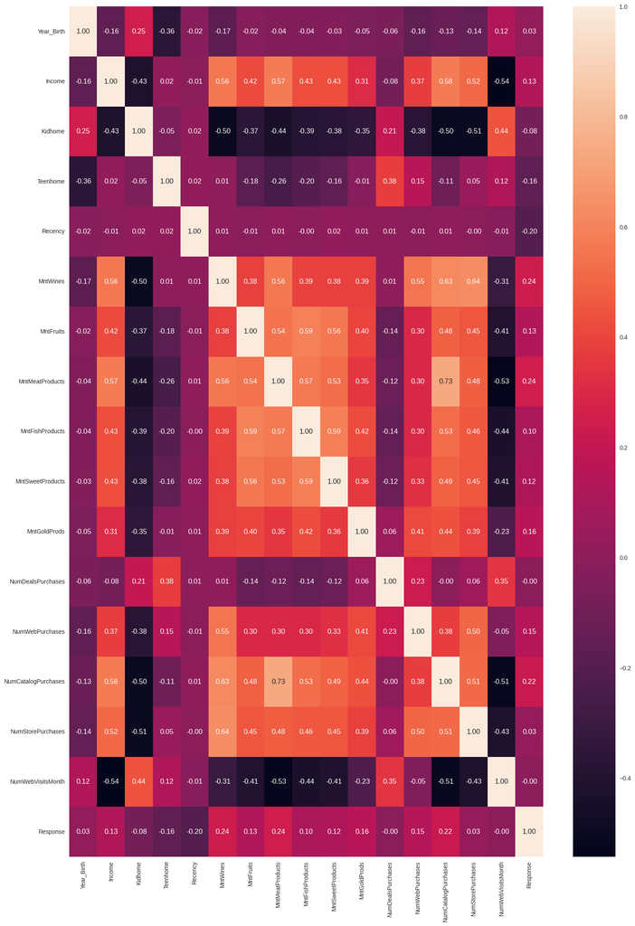

```python
plt.figure(figsize=(18,26))
sns.heatmap(df.corr(), annot=True, fmt='0.2f')
plt.show()
```

##### **Observations:**

What we can clearly identify is that: income has a positive correlation with the Mnt* variables, this means, the bigger income you have the more money you spent on buying these things.

Also, we can see that there is a negative correlation between the number of kids and the amount spent in products, especially in wine.

`MntMeatProducts` is highly correlated to the `NumCatalogPurchases`.

Also we can see that higher-income customers visit the website fewer times per month.

Before applying k-means, i will standarize the variables.

```python
scaler=StandardScaler()
df_for_kmeans = pd.DataFrame(scaler.fit_transform(df), columns=df.columns)
```

```python
df_for_kmeans.head()
```

|  | Year_Birth | Income | Kidhome | Teenhome | Recency | MntWines | MntFruits | MntMeatProducts | MntFishProducts | MntSweetProducts | MntGoldProds | NumDealsPurchases | NumWebPurchases | NumCatalogPurchases | NumStorePurchases | NumWebVisitsMonth | Response |
| --- | --- | --- | --- | --- | --- | --- | --- | --- | --- | --- | --- | --- | --- | --- | --- | --- | --- |
| 0 | -1.020549 | 0.226236 | -0.826656 | -0.931318 | 0.314628 | 0.976346 | 1.554146 | 1.668294 | 2.459827 | 1.464284 | 0.858539 | 0.342459 | 1.412990 | 2.493090 | -0.552287 | 0.686707 | 2.353446 |
| 1 | -1.277813 | -0.235464 | 1.039304 | 0.899702 | -0.375803 | -0.872996 | -0.636258 | -0.713547 | -0.647145 | -0.630712 | -0.731216 | -0.174417 | -1.125168 | -0.569221 | -1.169594 | -0.133538 | -0.424909 |
| 2 | -0.334514 | 0.753742 | -0.826656 | -0.931318 | -0.790062 | 0.356935 | 0.572241 | -0.179838 | 1.344972 | -0.149104 | -0.033275 | -0.691293 | 1.412990 | -0.228964 | 1.299634 | -0.543660 | -0.424909 |
| 3 | 1.294820 | -1.006583 | 1.039304 | -0.931318 | -0.790062 | -0.872996 | -0.560727 | -0.651796 | -0.500935 | -0.582551 | -0.750604 | -0.174417 | -0.762574 | -0.909478 | -0.552287 | 0.276585 | -0.424909 |
| 4 | 1.037556 | 0.232303 | 1.039304 | -0.931318 | 1.557405 | -0.392878 | 0.421179 | -0.219536 | 0.157012 | -0.004621 | -0.556731 | 1.376211 | 0.325208 | 0.111293 | 0.065020 | -0.133538 | -0.424909 |

```python
df_for_kmeans_copy = df_for_kmeans.copy(deep=True)
```

## **K-means Clustering**

#### **Question 7** : Select the appropriate number of clusters using the elbow Plot. What do you think is the appropriate number of clusters?

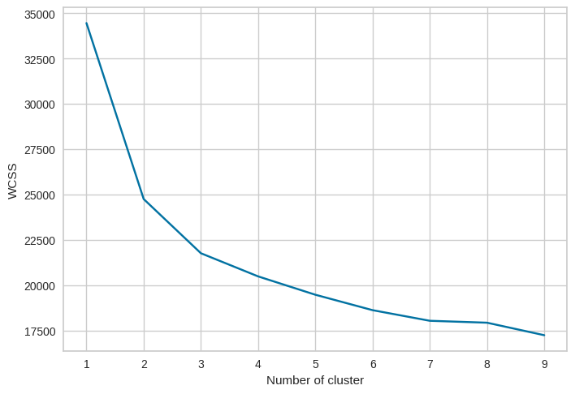

```python
# step 1
WCSS = {}
seed_value = 1
for k in range(1, 10):
    kmeans = KMeans(n_clusters=k, max_iter=1000, random_state=seed_value).fit(df_for_kmeans)
    WCSS[k] = kmeans.inertia_

# step 3
plt.figure()
plt.plot(list(WCSS.keys()), list(WCSS.values()), 'bx-')
plt.xlabel("Number of cluster")
plt.ylabel("WCSS")
plt.show()
```

##### **Observations:**

This suggest I should use 3 clusters. 3 represents the best trade-off between minimizing the WCSS and keeping the model simple and interpretable.

#### **Question 8** : finalize appropriate number of clusters by checking the silhoutte score as well. Is the answer different from the elbow plot?

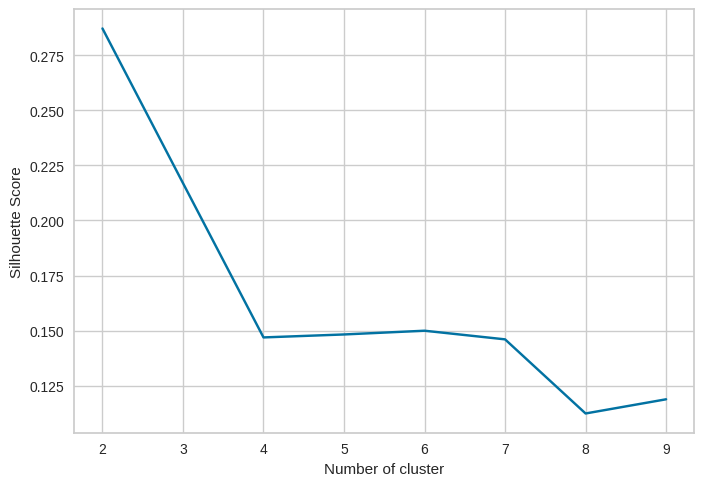

```python
#Empty dictionary to store the Silhouette score for each value of k
sc = {}

# iterate for a range of Ks and fit the scaled data to the algorithm. Store the Silhouette score for that k
for k in range(2, 10):
    kmeans = KMeans(n_clusters=k, random_state=seed_value).fit(df_for_kmeans)
    labels = kmeans.predict(df_for_kmeans)
    sc[k] = silhouette_score(df_for_kmeans, labels)

#Elbow plot
plt.figure()
plt.plot(list(sc.keys()), list(sc.values()), 'bx-')
plt.xlabel("Number of cluster")
plt.ylabel("Silhouette Score")
plt.show()
```

##### **Observations:**

This suggest i should use 2 or 3 clusters. Taking into consideration both graphs, I think i should use 3 cluster, which is the best scenario if we look at both graphs.

#### **Question 9**: Do a final fit with the appropriate number of clusters. How much total time does it take for the model to fit the data?

```python
start_time = time.time()

kmeans = KMeans(n_clusters=3, max_iter= 1000, random_state=1)
kmeans.fit(df_for_kmeans)
end_time = time.time()
total_time = end_time - start_time
print(f"Total time taken: {total_time} seconds")

df_for_kmeans_copy['Labels'] = kmeans.predict(df_for_kmeans)
df['Labels'] = kmeans.predict(df_for_kmeans)
original_df.loc[df.index, 'Labels'] = kmeans.predict(df_for_kmeans)
```

```
Total time taken: 0.009747743606567383 seconds
```

##### **Observations:**

It tooks 0.0097 seconds.

## **Cluster Profiling and Comparison**

#### **Question 10**: Perform cluster profiling using boxplots for the K-Means algorithm. Analyze key characteristics of each cluster and provide detailed observations.

```python
df.Labels.value_counts()
```

| Labels | count |
| --- | --- |
| 1 | 919 |
| 2 | 575 |
| 0 | 533 |

**dtype:** int64

Cluster 0 contains 533 values, cluster 1 contains 919 values and cluster 2 contains 575 values.

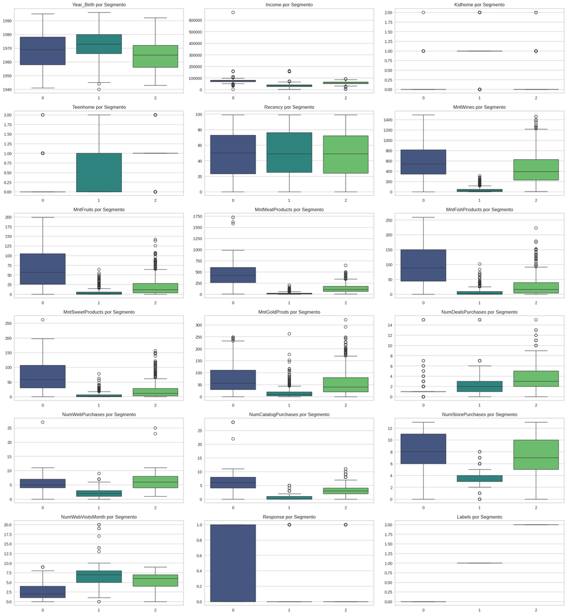

```python
key_vars = df.columns
plt.figure(figsize=(20, 25))

for i, col in enumerate(key_vars):
    plt.subplot(7, 3, i + 1)

    sns.boxplot(x='Labels', y=col, data=df, palette='viridis')

    plt.title(f'{col} por Segmento', fontsize=12)
    plt.xlabel('')
    plt.ylabel('')

plt.tight_layout()
plt.show()
```

##### **Observations:**

We can clearly identify three groups of people: high-income people (Cluster 0), low-income people (Cluster 1), and middle-income people (Cluster 2).

(CLUSTER 0) High-Income People Cluster: They spend the most on products in general. They buy the fewest discounted products and have the highest response rate to campaigns. 'Kidhome' and 'Teenhome' mostly have low values. They search the least on the web, however, they are the second group that buys the most through this channel. Apparently, they are the most loyal.

(CLUSTER 1) Low-Income People Cluster: They spend very little on products. They make the most visits to the web and also buy the least through this channel, an indication that they enter to compare prices. They have the highest presence of children. They are price-seekers with tight budgets.

#### **Question 11**: Perform cluster profiling on the data using a barplot for the K-Means algorithm. Provide insights and key observations for each cluster based on the visual analysis.

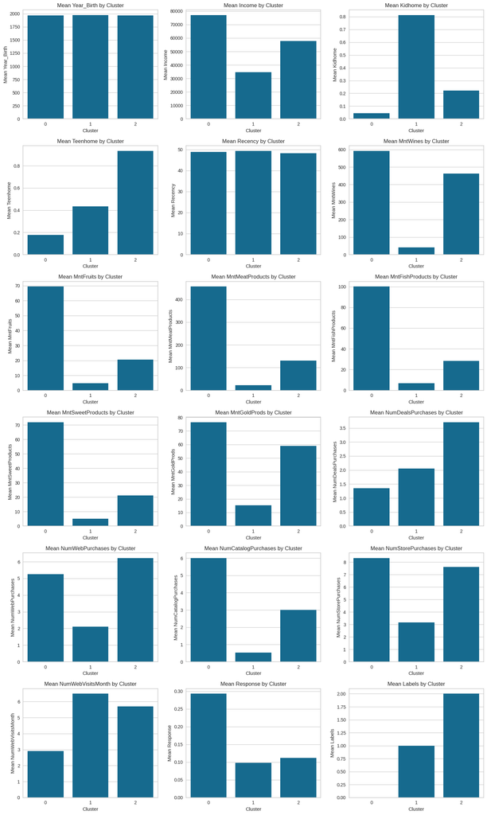

```python
cluster_means = df.groupby('Labels').mean()
features_to_plot = df.columns

plt.figure(figsize=(15, 25))
for i, feature in enumerate(features_to_plot):
    plt.subplot(6, 3, i + 1)
    sns.barplot(x=cluster_means.index, y=feature, data=cluster_means)
    plt.title(f'Mean {feature} by Cluster')
    plt.xlabel('Cluster')
    plt.ylabel(f'Mean {feature}')
    plt.xticks(rotation=0)

plt.tight_layout()
plt.show()
```

##### **Observations:**

The most important points were mentioned in the previous chart. I will extract the most important observations from this bar plot.

CLUSTER 0: Spending in all categories is the highest, especially on meat. The average campaign response rate is around 30%. They have the fewest children at home. They are the ones who buy the most via catalog.

CLUSTER 1: They have the highest number of 'Kidhome'. It is confirmed that they are the ones who visit the website the most and buy the least. They have a low response to campaigns.

CLUSTER 2: It is confirmed that they are very sensitive to discounts (numDealsPurchase) and have high spending on gold products. Furthermore, they are the ones who have the most teenagers in their homes.

## **Business Recommedations**

#### **Question 12**: Based on the cluster insights, what business recommendations can be provided?

For the high-income segment, marketing campaigns should be based on catalogs, as they use this channel quite a bit. For this group, discounted products are not necessary. Instead, the focus should be on good quality, especially for meat and wine. Premium sections could be created focusing on this type of client, where they have access to quality, expensive products.

For the low-income segment, campaigns must be focused on low product costs. Since this is the group that visits the web the most to look for prices, marketing campaigns should be focused on the website. There should be a big promotion of low-cost products to attract these clients. Mass offers could be sent on the web depending on whether the user belongs to this segment. These mass offers can be monitored by looking at the recency value. We also saw that they are the group with the most kids at home. Perhaps good prices could also be focused on children's products.

For the middle-income segment, considering that their spending is high on gold products and that they are the ones who buy the most discounted products, discounts could be applied to this type of product, which we know will appeal to them greatly. Furthermore, they are the ones who have the most teens at home, so discounts on products for teenagers can be promoted too.